# NewYork Uber Jan 2015 to June 2015 data

This dataset is courtesy of FiveThirtyEight from Kaggle. Since the data size is large, this folder doesnot contain any data but the link is provided below. https://www.kaggle.com/fivethirtyeight/uber-pickups-in-new-york-city

```python
# import necessary libraries
import numpy as np
import pandas as pd
import matplotlib.pyplot as plt
import seaborn as sns
%matplotlib inline
```

```python
import matplotlib
matplotlib.rcParams['figure.figsize'] = (15.0, 6.0)
```

```python
# Loading te dataset
uber = pd.read_csv('/home/rupakkarki/Desktop/datasets/uber-data/ride_data/uber-raw-data-janjune-15.csv')
```

## 1 - Data Exploration

```python
uber.shape
```

```
(14270479, 4)
```

This dataset is huge, the original csv file is over 500MB and we can see that there is data for more than 14 million uber pickups in just 6 months in NewYork alone.

```python
# Explore Head
uber.head()
```

|  | Dispatching_base_num | Pickup_date | Affiliated_base_num | locationID |
| --- | --- | --- | --- | --- |
| 0 | B02617 | 2015-05-17 09:47:00 | B02617 | 141 |
| 1 | B02617 | 2015-05-17 09:47:00 | B02617 | 65 |
| 2 | B02617 | 2015-05-17 09:47:00 | B02617 | 100 |
| 3 | B02617 | 2015-05-17 09:47:00 | B02774 | 80 |
| 4 | B02617 | 2015-05-17 09:47:00 | B02617 | 90 |

```python
uber.tail()
```

|  | Dispatching_base_num | Pickup_date | Affiliated_base_num | locationID |
| --- | --- | --- | --- | --- |
| 14270474 | B02765 | 2015-05-08 15:43:00 | B02765 | 186 |
| 14270475 | B02765 | 2015-05-08 15:43:00 | B02765 | 263 |
| 14270476 | B02765 | 2015-05-08 15:43:00 | B02765 | 90 |
| 14270477 | B02765 | 2015-05-08 15:44:00 | B01899 | 45 |
| 14270478 | B02765 | 2015-05-08 15:44:00 | B02682 | 144 |

#### Let's check for null values.

```python
uber.isnull().sum()
```

```
Dispatching_base_num         0
Pickup_date                  0
Affiliated_base_num     162195
locationID                   0
dtype: int64
```

```python
# Unique values
uber.nunique()
```

```
Dispatching_base_num          8
Pickup_date             2744783
Affiliated_base_num         284
locationID                  262
dtype: int64
```

```python
uber.dtypes
```

```
Dispatching_base_num    object
Pickup_date             object
Affiliated_base_num     object
locationID               int64
dtype: object
```

There are no missing values for the pickup date columns and that's preety much what we need for this dataset. We have to perform any data preprocessing for the pickup date column.

#### Making separate columns for month, day and hour

```python
# rename pickup date to Date
uber.rename(columns={'Pickup_date': 'Date'}, inplace=True)
```

```python
# convert to datetime field.
uber['Date'] = pd.to_datetime(uber['Date'])
```

```python
uber.dtypes
```

```
Dispatching_base_num            object
Date                    datetime64[ns]
Affiliated_base_num             object
locationID                       int64
dtype: object
```

The date column is converted to datetime

```python
# Let's extract the month, day and hour
uber['month'] = uber['Date'].dt.month
uber['day'] = uber['Date'].dt.day
uber['hour'] = uber['Date'].dt.hour
```

```python
# Just checking
uber.head()
```

|  | Dispatching_base_num | Date | Affiliated_base_num | locationID | month | day | hour |
| --- | --- | --- | --- | --- | --- | --- | --- |
| 0 | B02617 | 2015-05-17 09:47:00 | B02617 | 141 | 5 | 17 | 9 |
| 1 | B02617 | 2015-05-17 09:47:00 | B02617 | 65 | 5 | 17 | 9 |
| 2 | B02617 | 2015-05-17 09:47:00 | B02617 | 100 | 5 | 17 | 9 |
| 3 | B02617 | 2015-05-17 09:47:00 | B02774 | 80 | 5 | 17 | 9 |
| 4 | B02617 | 2015-05-17 09:47:00 | B02617 | 90 | 5 | 17 | 9 |

Let's map the month to its name

```python
month_names = {1: 'January',2: 'February',3: 'March',4: 'April',5: 'May',6: 'June'}
uber['month_name'] = uber['month'].map(month_names)
```

## 2 - Data Visualization and Analysis

Let's visualize the data from the modified dataset.

#### Number of pickups each month

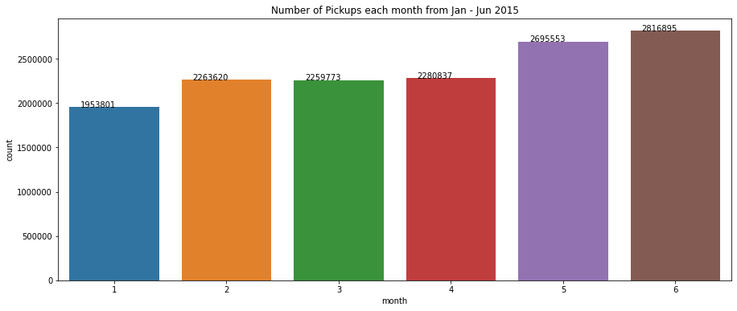

```python
ax = sns.countplot(x='month', data=uber)
plt.ticklabel_format(style='plain', axis='y', useOffset=False)
plt.title("Number of Pickups each month from Jan - Jun 2015")
for p in ax.patches:
        ax.annotate('{}'.format(p.get_height()), (p.get_x()+0.1, p.get_height()+50))
```

We can see the trend here that in 2015, the pickup numbers have been increasing throughout the first half. Though the numbers were fairly similar from February through April, in may and June the numbers increased significantly.

#### No. of pickups each day

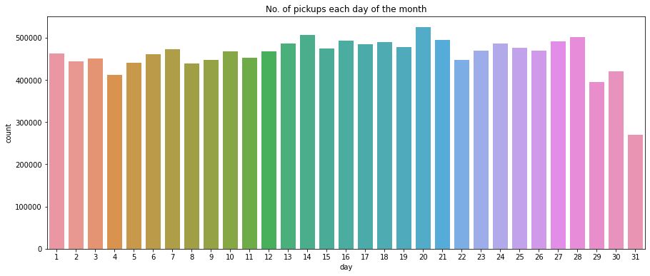

```python
ax = sns.countplot(x='day', data=uber)
plt.title("No. of pickups each day of the month")
plt.ticklabel_format(style='plain', axis='y', useOffset=False)
```

The number of pickus are more during the mid of any month and the lowest towards the end of the month during these 6 months.

#### No. of pickups across different hours of the day

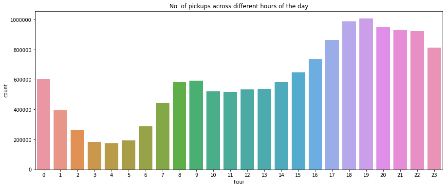

```python
sns.countplot(x='hour', data=uber)
plt.title("No. of pickups across different hours of the day")
plt.ticklabel_format(style='plain', axis='y', useOffset=False)
```

#### According to weekday

```python
uber['DayOfWeek'] = uber['Date'].dt.dayofweek
```

```python
dayOfWeek={0:'Monday', 1:'Tuesday', 2:'Wednesday', 3:'Thursday', 4:'Friday', 5:'Saturday', 6:'Sunday'}
uber['DayOfWeek'] = uber['DayOfWeek'].map(dayOfWeek)
```

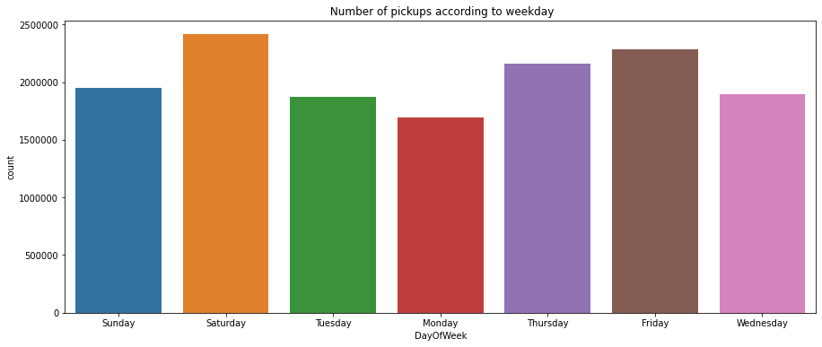

```python
sns.countplot(x='DayOfWeek', data=uber)
plt.title(" Number of pickups according to weekday")
plt.ticklabel_format(style='plain', axis='y', useOffset=False)
```

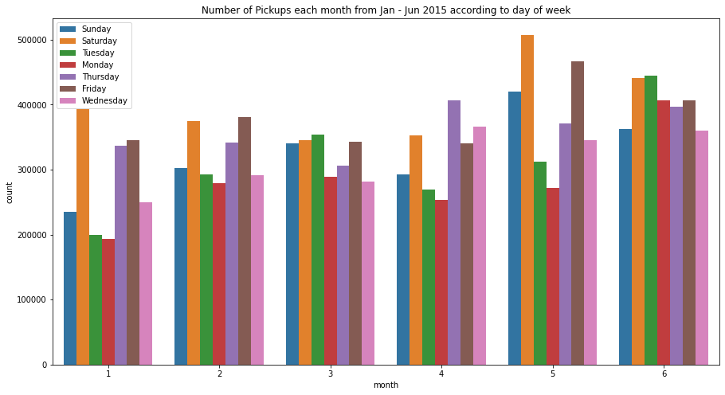

```python
plt.figure(figsize=(15, 8))
sns.countplot(x='month', data=uber, hue='DayOfWeek')
plt.ticklabel_format(style='plain', axis='y', useOffset=False)
plt.legend(loc='best')
plt.title("Number of Pickups each month from Jan - Jun 2015 according to day of week")
plt.show()
```